# Lord of the Rings TCG Analysis

### Cleaning the Data

```r
cards <- read.csv("AllCardData.csv")

#distinguishing Free Peoples and Shadow cards
free <- c("Dwarven", "Elven", "Gandalf", "Gollum", "Gondor", "Rohan", "Shire")

cards$Side <- rep(NA,length(cards$Title))
for(i in 1:length(cards$Title)) {
  if(cards$Culture[i] == free[1]) {
    cards$Side[i] <- "Free"
  } else if (cards$Culture[i] == free[2]) {
    cards$Side[i] <- "Free"
  } else if (cards$Culture[i] == free[3]) {
    cards$Side[i] <- "Free"
  } else if (cards$Culture[i] == free[4]) {
    cards$Side[i] <- "Free"
  } else if (cards$Culture[i] == free[5]) {
    cards$Side[i] <- "Free"
  } else if (cards$Culture[i] == free[6]) {
    cards$Side[i] <- "Free"
  } else if (cards$Culture[i] == free[7]) {
    cards$Side[i] <- "Free"
  } else {
    cards$Side[i] <- "Shadow"
  }
}


#removing duplicate words within the same card
rem_dup.one <- function(x){
   paste(unique(tolower(trimws(unlist(strsplit(x,split="(?!')[ [:punct:]]",
                                               fixed=F,perl=T))))),collapse = " ")
 }
cards$Game.text.unique <- NA
N <- length(cards$Game.text)

for (i in 1:N) {
  holder <- cards$Game.text[i]
  holder <- rem_dup.one(holder)
  holder <- str_replace_all(holder, "[[:digit:]]", "")
  cards$Game.text.unique[i] <- holder
}

#removing duplicate cards from different promotional packs
cards_clean <- cards[!duplicated(cards$Game.text.unique),]
cards_clean <- subset(cards_clean, Title != "Olog-Hai Bestial (P)") #French version of "Beastly Olog-Hai"

#listing all the words from each card to get a count of the number of cards with each word
all.words <- NULL

for(i in 1:length(cards_clean$Game.text.unique)) {
  words <- str_subset(str_split(cards_clean$Game.text.unique[i], " ", simplify = TRUE), ".+")
  all.words <- append(all.words, words)
}

Word_Freq_All <- data.frame("Words" = unique(all.words), "Freq" = rep(NA, length(unique(all.words))))

for(i in 1:length(Word_Freq_All$Words)) {
  Word_Freq_All$Freq[i] <- table(all.words)[[Word_Freq_All$Words[i]]]
}

#subsetting total cards dataframe to focus on companions and minions
cards.sub <- na.omit(cards_clean[,c(2,4,7:9, 19)])
```

In order to run some analyses on the cards and how they may be chosen based on Twilight, Strength, or Health, they need to be cleaned up a bit. In its raw state, there are 3038 cards to sort through, and not all of them are relevant to this initial stage of the analysis.

After taking a subset of all the cards, there are a total of 1222 to run through this analysis.

### Descriptive Stats

##### Twilight

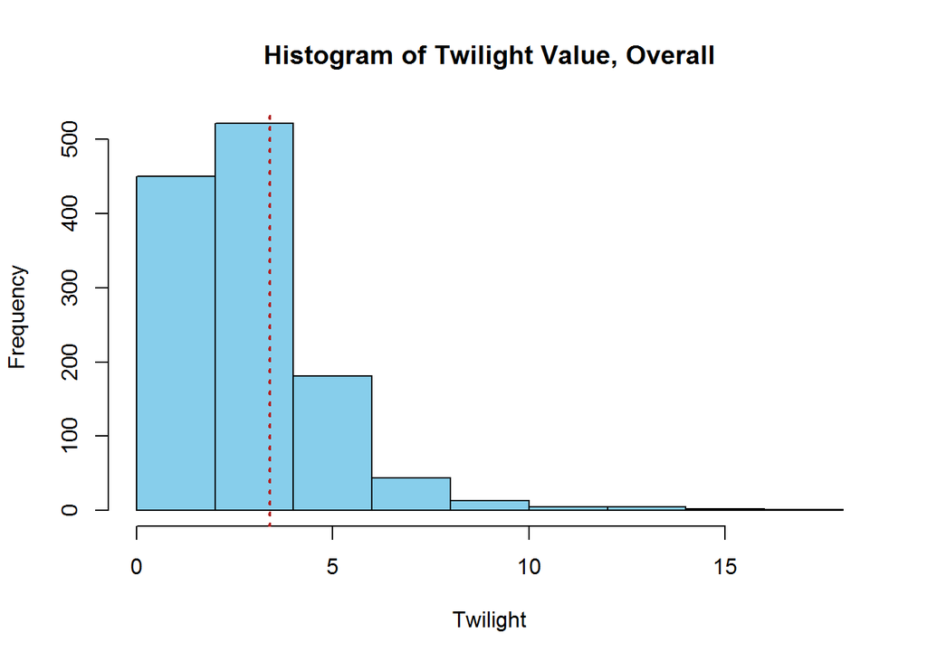

```r
hist(cards.sub$Twilight,
     col = "skyblue",
     xlab = "Twilight", main = "Histogram of Twilight Value, Overall")
abline(v = mean(cards.sub$Twilight), col = "firebrick", lwd = 2, lty = 3)
```

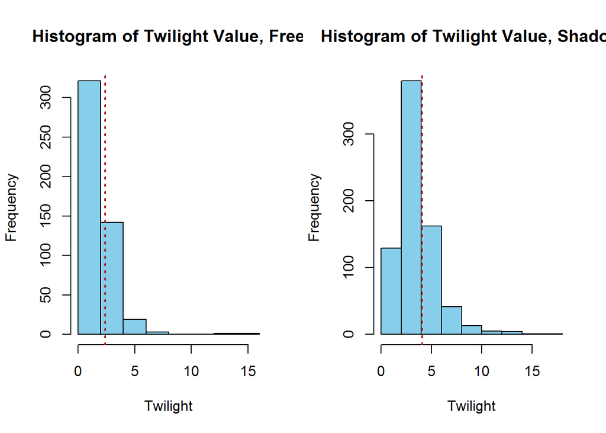

```r
par(mfrow = c(1,2))

hist(subset(cards.sub, Side == "Free")$Twilight,
     col = "skyblue",
     xlab = "Twilight", main = "Histogram of Twilight Value, Free")
abline(v = mean(subset(cards.sub, Side == "Free")$Twilight), col = "firebrick", lwd = 2, lty = 3)

hist(subset(cards.sub, Side == "Shadow")$Twilight,
     col = "skyblue",
     xlab = "Twilight", main = "Histogram of Twilight Value, Shadow")
abline(v = mean(subset(cards.sub, Side == "Shadow")$Twilight), col = "firebrick", lwd = 2, lty = 3)
```

##### Strength

[figure not shown]

```r
hist(cards.sub$STR,
     col = "skyblue",
     xlab = "Twilight", main = "Histogram of Twilight Value, Overall")
abline(v = mean(cards.sub$STR), col = "firebrick", lwd = 2, lty = 3)
```

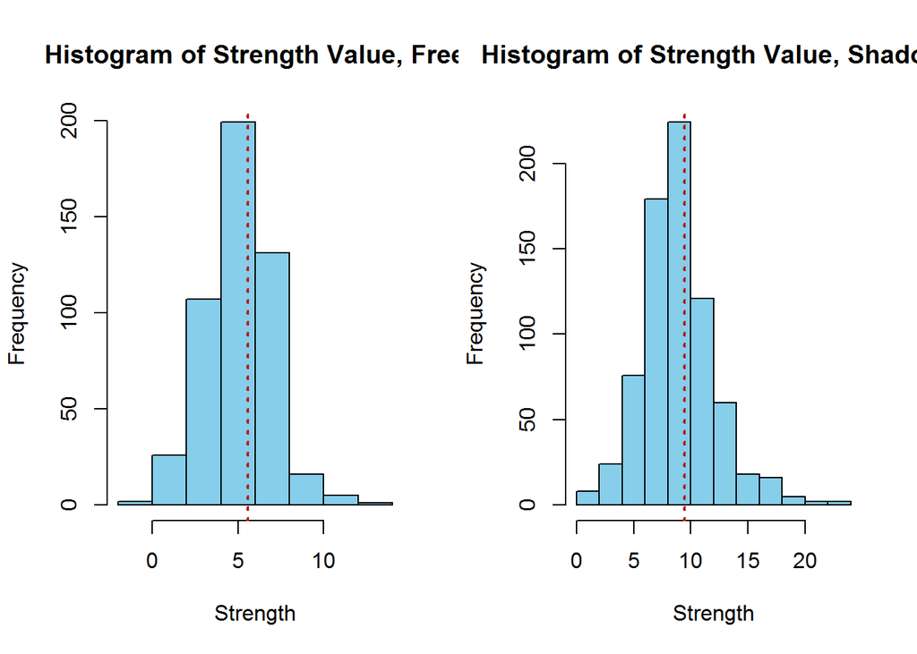

```r
par(mfrow = c(1,2))

hist(subset(cards.sub, Side == "Free")$STR,
     col = "skyblue",
     xlab = "Strength", main = "Histogram of Strength Value, Free")
abline(v = mean(subset(cards.sub, Side == "Free")$STR), col = "firebrick", lwd = 2, lty = 3)

hist(subset(cards.sub, Side == "Shadow")$STR,
     col = "skyblue",
     xlab = "Strength", main = "Histogram of Strength Value, Shadow")
abline(v = mean(subset(cards.sub, Side == "Shadow")$STR), col = "firebrick", lwd = 2, lty = 3)
```

##### Health

[figure not shown]

```r
hist(cards.sub$HP,
     col = "skyblue",
     xlab = "Twilight", main = "Histogram of Twilight Value, Overall")
abline(v = mean(cards.sub$HP), col = "firebrick", lwd = 2, lty = 3)
```

[figure not shown]

```r
par(mfrow = c(1,2))

hist(subset(cards.sub, Side == "Free")$HP,
     col = "skyblue",
     xlab = "Health", main = "Histogram of Health Value, Free")
abline(v = mean(subset(cards.sub, Side == "Free")$HP), col = "firebrick", lwd = 2, lty = 3)

hist(subset(cards.sub, Side == "Shadow")$HP, breaks = 10,
     col = "skyblue",
     xlab = "Health", main = "Histogram of Health Value, Free")
abline(v = mean(subset(cards.sub, Side == "Shadow")$HP), col = "firebrick", lwd = 2, lty = 3)
```

##### Overall

```r
stargazer(subset(cards.sub, Side == "Free"),
          title = "Descriptive Stats - Free Peoples",
          digits = 2,
          align = TRUE,
          type = s_type)
```

**Descriptive Stats - Free Peoples**

| Statistic | N | Mean | St. Dev. | Min | Max |
| --- | --- | --- | --- | --- | --- |
| Twilight | 487 | 2.37 | 1.43 | 0 | 15 |
| STR | 487 | 5.57 | 2.10 | -2 | 14 |
| HP | 487 | 3.26 | 0.90 | -2 | 9 |

```r
stargazer(subset(cards.sub, Side == "Shadow"),
          title = "Descriptive Stats - Shadow",
          digits = 2,
          align = TRUE,
          type = s_type)
```

**Descriptive Stats - Shadow**

| Statistic | N | Mean | St. Dev. | Min | Max |
| --- | --- | --- | --- | --- | --- |
| Twilight | 735 | 4.08 | 2.09 | 0 | 18 |
| STR | 735 | 9.44 | 3.17 | 1 | 24 |
| HP | 735 | 2.51 | 0.87 | 1 | 6 |

Here are some observations that I made while combing through these descriptive statistics:

- **Twilight**

Twilight values are strongly right skewed, meaning that the majority of Twilight values are between 0 and 5. This is true for the combined and the separated subsets.

- **Strength**

Strength values are fairly normally distributed for the Free Peoples and the Shadow cards. This means that one does not have an inherent advantage over the other. That being said, there is a wider spread for the Shadow than the Free Peoples. With the Free Peoples, about 68% of the cards have a strength between 3 and 8, while the Shadow’s strength is between 6 and 13. This feels like a pretty significant difference, but further analysis will have to take place a later section.

- **Health**

The Health of each of these cards is an interesting one. When looking at the data all together, it seems to be normally distributed, which would mean that we are able to make a similar inference as with Strength. The interesting bit comes out when we look the difference between the Free Peoples and the Shadow. The Free Peoples have a normal distribution, but the Shadow show a right skewed distribution. This makes sense for the game because it is structured in such a way that the Shadow is, generally, in play for a single turn, while the Free Peoples, generally, stay in play until they are defeated. In this setting, you would want a wider distribution of values, and a higher level in order to outlast your opponent.

### Graphical Profiles

As a final portion within the Descriptive portion of this analysis, I wanted to look at the connection of a card’s Health and Strength in relation to their Twilight cost. In a game, I would want to look for a high level of Health and Strength along with a low level of Twilight cost. This would make it easier to play stronger cards without sacrificing Twilight to your opponent.

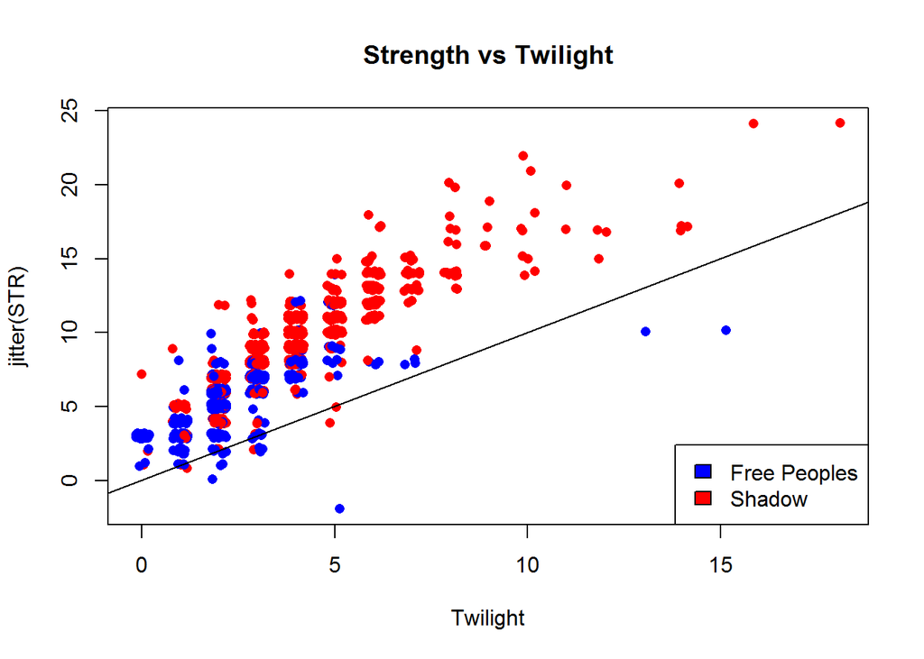

```r
#Identifying cards with a higher strength than their twilight
cards.sub$diff.str <- cards.sub$STR - cards.sub$Twilight
cards.sub$good.str <- cards.sub$diff.str > 0

#Identifying cards with a higher health than their twilight
cards.sub$diff.hlth <- cards.sub$HP - cards.sub$Twilight
cards.sub$good.hlth <- cards.sub$diff.hlth > 0

#Identifying cards that have a higher strength AND health than twilight
cards.sub$all.good <- cards.sub$good.str + cards.sub$good.hlth == 2

par(mfrow = c(1,1))
colors <- c("blue", "red")

plot(jitter(STR) ~ jitter(Twilight), data = cards.sub,
     pch = 16,
     col = colors[factor(cards.sub$Side)],
     main = "Strength vs Twilight",
     xlab = "Twilight")
abline(a = 0, b = 1)
legend("bottomright",
       legend = c("Free Peoples", "Shadow"),
       fill = c("blue", "red"))
```

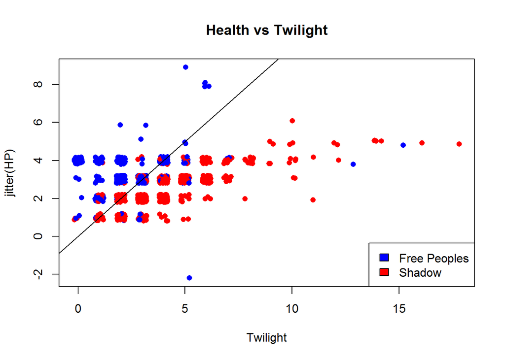

```r
plot(jitter(HP) ~ jitter(Twilight), data = cards.sub,
     pch = 16,
     col = colors[factor(cards.sub$Side)],
     main = "Health vs Twilight",
     xlab = "Twilight")
abline(a = 0, b = 1)
legend("bottomright",
       legend = c("Free Peoples", "Shadow"),
       fill = c("blue", "red"))
```

These graphs tell a different story. The line shows where Twilight and either Strength or Health, respectively, are equal. Points that are above the line represent cards that have higher Strength or Health than they do Twilight cost. When picking cards, that is where I would start.

when looking at the graph for strength, it is interesting that the majority of cards sit above this line. This removes a handful of cards from the running, but does not whittle down a significant amount of the 1222 cards that we have available.

The graph when it comes to health, is very interesting. There are a good amount of cards that are above our line from the Free Peoples cards (65% to be exact). But there are only 28 cards above that line, which represents 4% of the Shadow cards. This, will be an interesting point to explore in the next section.

#### Both Criteria

```r
above.lines <- subset(cards.sub, all.good == TRUE)

table(above.lines$Culture[above.lines$Side == "Free"]) %>%
  pander()
```

| Dwarven | Elven | Gandalf | Gollum | Gondor | Rohan | Shire |
| --- | --- | --- | --- | --- | --- | --- |
| 31 | 70 | 17 | 27 | 38 | 54 | 73 |

```r
table(above.lines$Culture[above.lines$Side == "Shadow"]) %>%
  pander()
```

| Isengard | Men | Moria | Orc | Raider | Sauron | Uruk-hai | Uruk-Hai |
| --- | --- | --- | --- | --- | --- | --- | --- |
| 10 | 5 | 1 | 2 | 1 | 6 | 2 | 1 |

```r
reactable(above.lines[,c(1:6)])
```

| Title | Culture | Twilight | STR | HP | Side |
| --- | --- | --- | --- | --- | --- |
| •Arwen, Maiden of Rivendell (D) | Elven | 2 | 9 | 4 | Free |
| •Gandalf, Stormcrow (D) | Gandalf | 3 | 10 | 4 | Free |
| Moria Skirmishers (D) | Moria | 3 | 11 | 4 | Shadow |
| •Eomer, Forthwith Banished (D) | Rohan | 2 | 10 | 6 | Free |
| •Theodred, Second Marshal of the Mark (D) | Rohan | 2 | 6 | 3 | Free |
| •Bilbo, Aged Ring-bearer (D) | Shire | 2 | 3 | 4 | Free |
| •Orophin, Brother of Haldir (P) | Elven | 2 | 6 | 3 | Free |
| •Grima, Footman of Saruman (P) | Men | 2 | 4 | 3 | Shadow |
| •Hama, Captain of the King's Guard (P) | Rohan | 2 | 6 | 3 | Free |
| •Eowyn, Restless Warrior (P) | Rohan | 2 | 6 | 3 | Free |

[output cut: 328 more lines]

### Text Analysis

##### Overall Frequency

[figure not shown]

```r
ggplot(Word_Freq_All, aes(x = Words, y = Freq)) +
  geom_bar(stat = "identity", fill = "skyblue", color = "black")
```

After taking out 93 common words, or words that were deemed less important for this analysis, we are left with the following graph.

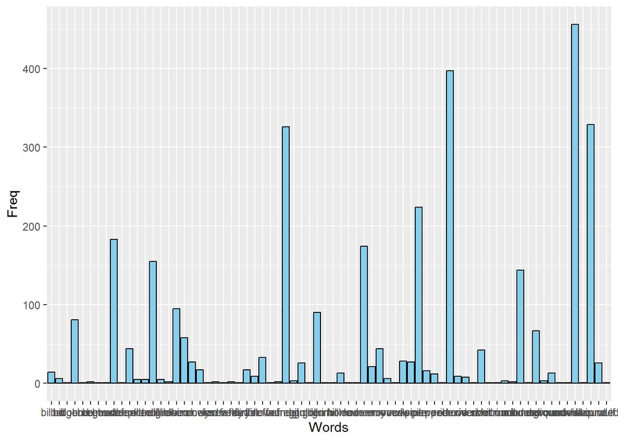

```r
Word_Freq_dim <- Word_Freq_All[!grepl(paste(transition.words, collapse="|"),
                                       Word_Freq_All$Words),]

ggplot(Word_Freq_dim, aes(x = Words, y = Freq)) +
  geom_bar(stat = "identity", fill = "skyblue", color = "black")
```

Still completely unreadable, but a little better.

##### Side Splitting

Let’s see if splitting them by Free Peoples vs Shadow cards makes a difference.

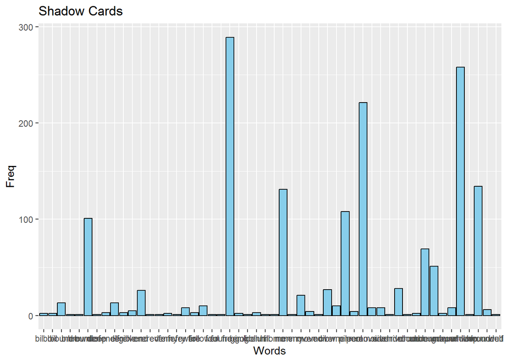

```r
#creating list of words on Shadow cards
shad.words <- NULL

for(i in 1:length(subset(cards_clean, Side == "Shadow")$Game.text.unique)) {
  words <- str_subset(str_split(subset(cards_clean, Side == "Shadow")$Game.text.unique[i], " ", simplify = TRUE), ".+")
  shad.words <- append(shad.words, words)
}

Word_Freq_shad <- data.frame("Words" = unique(shad.words), "Freq" = rep(NA, length(unique(shad.words))))

for(i in 1:length(Word_Freq_shad$Words)) {
  Word_Freq_shad$Freq[i] <- table(shad.words)[[Word_Freq_shad$Words[i]]]
}

Word_Freq_shad.dim <- Word_Freq_shad[!grepl(paste(transition.words, collapse="|"),
                                       Word_Freq_shad$Words),]

#creating list of words on Free Peoples cards
free.words <- NULL

for(i in 1:length(subset(cards_clean, Side == "Free")$Game.text.unique)) {
  words <- str_subset(str_split(subset(cards_clean, Side == "Free")$Game.text.unique[i], " ", simplify = TRUE), ".+")
  free.words <- append(free.words, words)
}

Word_Freq_free <- data.frame("Words" = unique(free.words), "Freq" = rep(NA, length(unique(free.words))))

for(i in 1:length(Word_Freq_free$Words)) {
  Word_Freq_free$Freq[i] <- table(free.words)[[Word_Freq_free$Words[i]]]
}

Word_Freq_free.dim <- Word_Freq_free[!grepl(paste(transition.words, collapse="|"),
                                       Word_Freq_free$Words),]

#graphs of both
ggplot(Word_Freq_shad.dim, aes(x = Words, y = Freq)) +
  geom_bar(stat = "identity", fill = "skyblue", color = "black") +
  ggtitle("Shadow Cards")
```

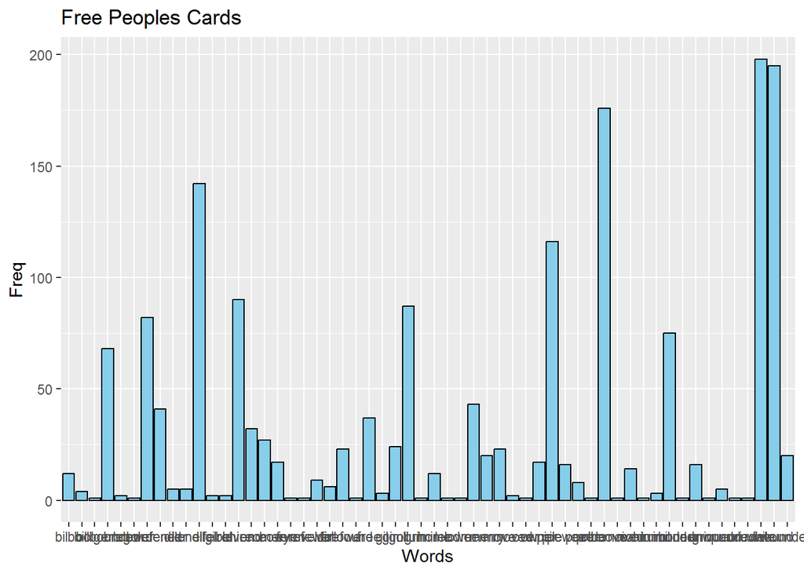

```r
ggplot(Word_Freq_free.dim, aes(x = Words, y = Freq)) +
  geom_bar(stat = "identity", fill = "skyblue", color = "black") +
  ggtitle("Free Peoples Cards")
```

###### Above 50 Cards

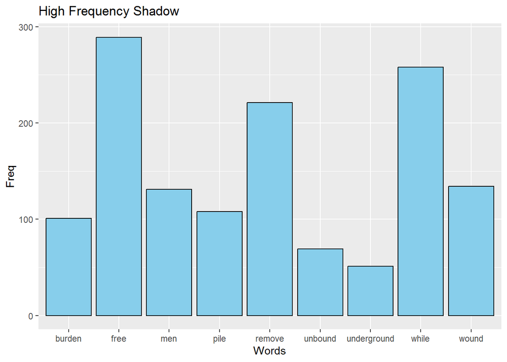

```r
word_freq_shad.high <- subset(Word_Freq_shad.dim, Freq > 50)
ggplot(word_freq_shad.high, aes(x = Words, y = Freq)) +
  geom_bar(stat = "identity", fill = "skyblue", color = "black") +
  ggtitle("High Frequency Shadow")
```

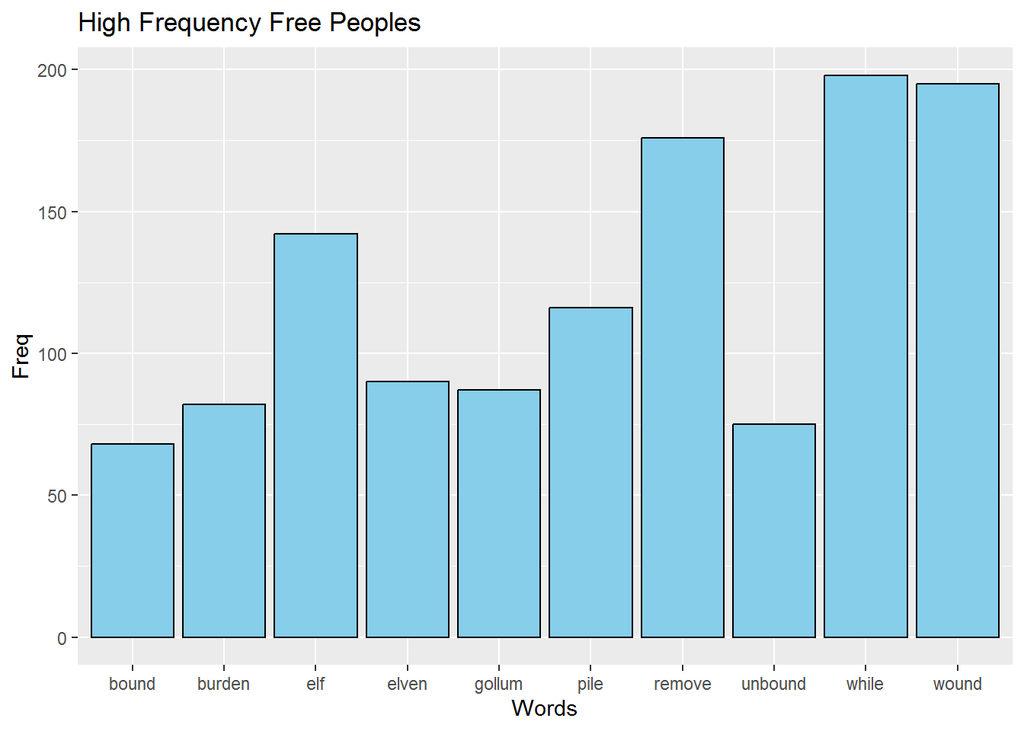

```r
word_freq_free.high <- subset(Word_Freq_free.dim, Freq > 50)
ggplot(word_freq_free.high, aes(x = Words, y = Freq)) +
  geom_bar(stat = "identity", fill = "skyblue", color = "black") +
  ggtitle("High Frequency Free Peoples")
```

###### Below 50 Cards

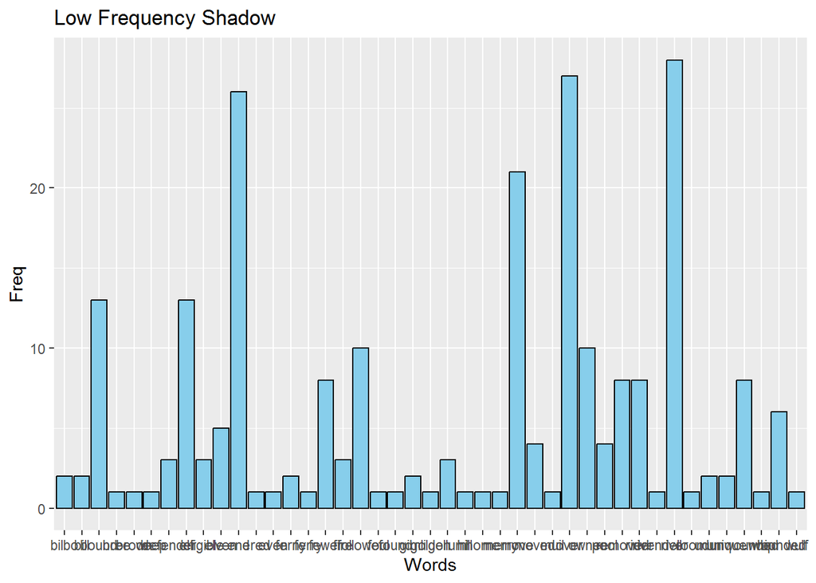

```r
word_freq_shad.high <- subset(Word_Freq_shad.dim, Freq < 50)
ggplot(word_freq_shad.high, aes(x = Words, y = Freq)) +
  geom_bar(stat = "identity", fill = "skyblue", color = "black") +
  ggtitle("Low Frequency Shadow")
```

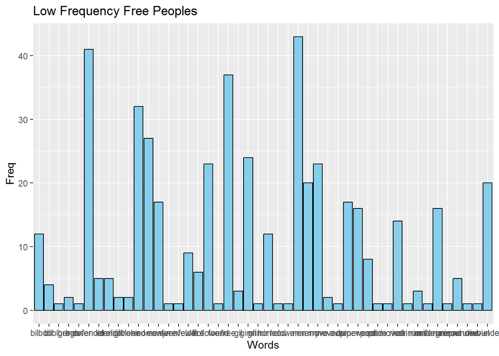

```r
word_freq_free.high <- subset(Word_Freq_free.dim, Freq < 50)
ggplot(word_freq_free.high, aes(x = Words, y = Freq)) +
  geom_bar(stat = "identity", fill = "skyblue", color = "black") +
  ggtitle("Low Frequency Free Peoples")
```